# Week 12 Independent Project

# Exploratory Data Analysis

## Univariate Analysis

### Measures of Central Tendency

### 1)Mean

```r
#Mean
mean(Advert$Daily.Time.Spent.on.Site)
```

```
## [1] 65.0002
```

The average Time Spent Daily on Site is 65

```r
# Mean Area.Income
mean(Advert$Area.Income)
```

```
## [1] 55000
```

The average area income in our dataset is 55000

```r
# Mean age
mean(Advert$Age)
```

```
## [1] 36.009
```

The average age of individuals in our dataset is 36 years

```r
#Mean for Daily.Internet.Usage
mean(Advert$Daily.Internet.Usage)
```

```
## [1] 180.0001
```

The average internet usage daily is 180

### 2)Median

```r
#Median Daily.Time.Spent.on.Site
median(Advert$Daily.Time.Spent.on.Site)
```

```
## [1] 68.215
```

The Median Time Spent Daily on Site is 68.215 minutes

```r
# median Area.Income
median(Advert$Area.Income)
```

```
## [1] 57012.3
```

The Median income in our dataset is 57012.3

```r
# Median age
median(Advert$Age)
```

```
## [1] 35
```

The median age of individuals in our dataset is 35 years

```r
#Median for Daily.Internet.Usage
median(Advert$Daily.Time.Spent.on.Site)
```

```
## [1] 68.215
```

### 3)Mode

```r
# Define a function for getting the mode

getmode <- function(v) {
  uniqv <- unique(v)
  uniqv[which.max(tabulate(match(v, uniqv)))]
}

#mode for Daily.Internet.Usage
getmode(Advert$Daily.Internet.Usage)
```

```
## [1] 167.22
```

The mode for daily internet usage is 167.22

```r
#Mode for age
getmode(Advert$Age)
```

```
## [1] 31
```

The mode of age in our dataset is 31

```r
getmode(Advert$Daily.Time.Spent.on.Site)
```

```
## [1] 62.26
```

## Measures of Dispersion

### 1)Range

```r
range(Advert$Age)
```

```
## [1] 19 61
```

```r
range(Advert$Daily.Time.Spent.on.Site)
```

```
## [1] 32.60 91.43
```

The range of Time Spent Daily on Site is between 32.60 and 91.43

```r
range(Advert$Daily.Internet.Usage)
```

```
## [1] 104.78 269.96
```

The range for Daily.Internet.Usage is between 104.78 and 269.96

```r
range(Advert$Area.Income)
```

```
## [1] 13996.5 79484.8
```

The range for area income is between 13996.5 and 79484.8

#### 2)Variance

```r
#Variance for Age
var(Advert$Age)
```

```
## [1] 77.18611
```

The variance in the age is 77.18

```r
#Variance for Time Spent on Site
var(Advert$Daily.Time.Spent.on.Site)
```

```
## [1] 251.3371
```

The variance in the daily time spent on site is 251.33

```r
#Variance for Internet Usage
var(Advert$Daily.Internet.Usage)
```

```
## [1] 1927.415
```

The variance in the daily internet usage is 1927.415

### 3)Standard deviation

```r
#Standard deviation for Age
sd(Advert$Age)
```

```
## [1] 8.785562
```

Standard deviation for Age is 8.785

```r
#Standard deviation for Internet Usage
sd(Advert$Daily.Internet.Usage)
```

```
## [1] 43.90234
```

Standard deviation for daily Internet Usage is 43.90234

```r
#Standard deviation for Time Spent on Site
sd(Advert$Daily.Time.Spent.on.Site)
```

```
## [1] 15.85361
```

Standard deviation for Time Spent on Site is 15.85361

### 3)Quantiles

```r
#time quantiles for daily Internet Usage
quantile(Advert$Daily.Internet.Usage)
```

```
##       0%      25%      50%      75%     100%
## 104.7800 138.8300 183.1300 218.7925 269.9600
```

The first quantile in the daily Internet Usage is 138.83 The third quantile in the daily Internet Usage is 218.7925

```r
#time quantiles for age
quantile(Advert$Age)
```

```
##   0%  25%  50%  75% 100%
##   19   29   35   42   61
```

The first quantile in age is 29 The third quantile in age is 42

```r
#time quantiles for Daily.Time.Spent.on.Site
quantile(Advert$Daily.Time.Spent.on.Site)
```

```
##      0%     25%     50%     75%    100%
## 32.6000 51.3600 68.2150 78.5475 91.4300
```

The first quantile in the daily time spent is 51.36 minutes. The third quantile in the daily time spent on site is 78.55 minutes.

### Frequency Tables

```r
# Gender Frequency Table
# 0 symbolizes female while 1 is male
gender <- table(Advert$Male)
gender
```

```
##
##   0   1
## 519 481
```

From the frequency table, we can see that there are 519 females and 481 males in our dataset.

```r
# Country Frequency Table
countries <- (table(Advert$Country))
# Sort the table so as to find the country with the most individuals in our dataset
sorted_countries <- sort(countries, decreasing = TRUE)
head(sorted_countries)
```

```
##
## Czech Republic         France    Afghanistan      Australia         Cyprus
##              9              9              8              8              8
##         Greece
##              8
```

We can say that both Czech Republic and France had 9 individuals, while Afghanistan, Australia, Cyprus and Greece all had 8 individuals each.

```r
# Clicked on Ad Frequency Table
# 0 means the individual did not click on the ad, 1 means the individual clicked on an ad
clicked <- table(Advert$Clicked.on.Ad)
clicked
```

```
##
##   0   1
## 500 500
```

From the frequency table we can say that 500 people clicked on the add and 500 people did not click on the add

```r
# City Frequency Table
city <- table(Advert$City)
# Sort the table so as to find the city with the most individuals in our dataset
sorted_city <- sort(city, decreasing = TRUE)
head(sorted_city)
```

```
##
##       Lisamouth    Williamsport Benjaminchester       East John    East Timothy
##               3               3               2               2               2
##        Johnstad
##               2
```

From the frequecy table we can say that Lisamouth and Williamsport had 3 people and the other cities had 2 people

```r
# Age Frequency Table
age <- table(Advert$Age)
# Sort the table so as to find the age with the most individuals
sorted_age <- sort(age, decreasing = TRUE)
head(sorted_age)
```

```
##
## 31 36 28 29 33 30
## 60 50 48 48 43 39
```

### Graphical Plots

#### 1)Histograms

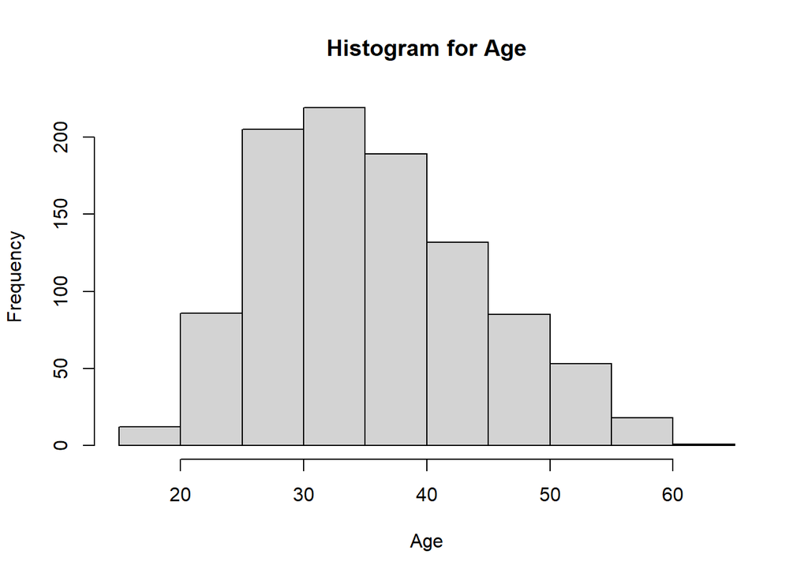

```r
#histogram for the age column
hist(Advert$Age, xlab = 'Age', main = 'Histogram for Age')
```

From the histogram, we can also tell that age 25 - 35 had the highest frequency in the dataset.

### 2)Barplot

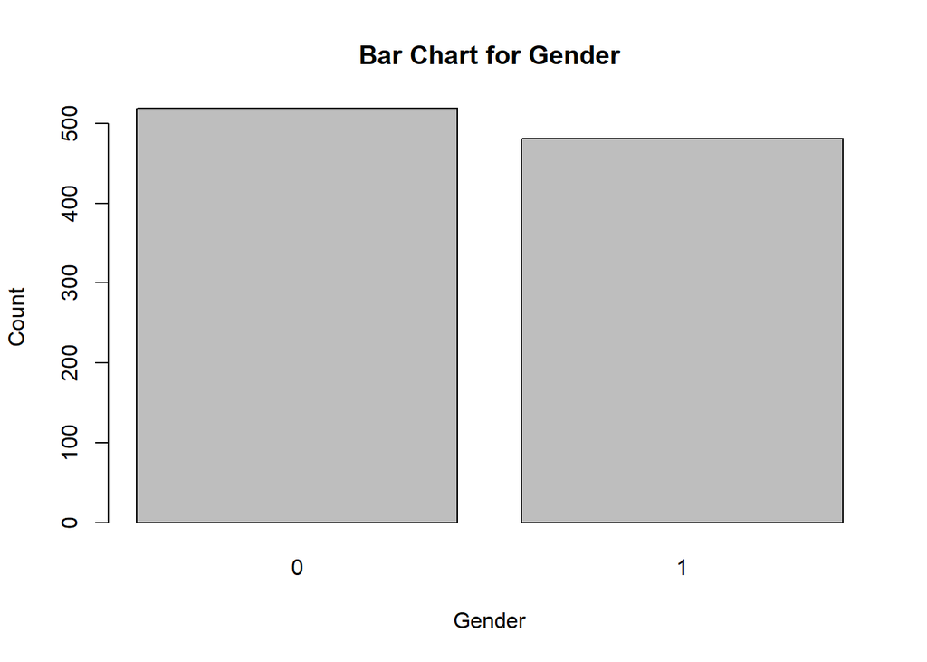

```r
# Gender barplot
barplot(gender, xlab = 'Gender', ylab = 'Count', main = 'Bar Chart for Gender')
```

From the bar chart, we can tell that 0(female) had more people that 1(male) in our dataset.

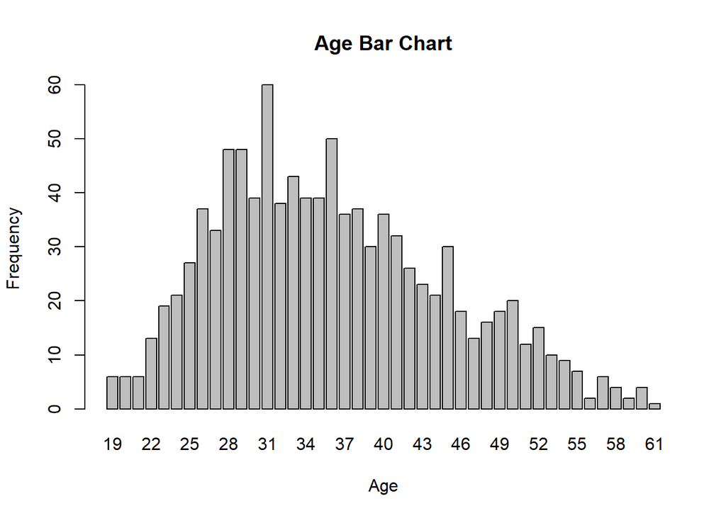

```r
# bar plot for age
age <- table(Advert$Age)
# Then we plot a bar chart
barplot(age, xlab ='Age', ylab ='Frequency', main ='Age Bar Chart')
```

From the bar chart above, we can tell that age 31 had the highest frequency in the dataset.

## Bivariate Analysis

### Covariance

```r
#covariance between age and internet usage
age <- Advert$Age
units <- Advert$Daily.Internet.Usage
cov(age, units)
```

```
## [1] -141.6348
```

There is a negative covariance(-141.6348) between age and the daily usage of internet which means that the older a person is, the less units they use on internet daily.

```r
# covariance between age and the daily time spent on the site
age <- Advert$Age
time <- Advert$Daily.Time.Spent.on.Site
cov(age, time)
```

```
## [1] -46.17415
```

There is a negative covariance(-46.17415) between age and the daily time Spent on Site which means that the older a person is, the less units they visit the site.

### Correlation

```r
# correlation between age and daily internet usage
cor(age, units)
```

```
## [1] -0.3672086
```

There is a negative linear relationship between age and the daily internet usage.

```r
#  correlation between age and time spent on site
cor(age, time)
```

```
## [1] -0.3315133
```

There is a negative linear relationship between age and the daily time spent on the site.

### Correlation Matrix

First we load the corrplot library which enables us to plot a correlation matrix.

```r
 #correlation library
library(corrplot) # This library allows us to plot correlation.
```

We go ahead to create a subset that holds the numerical columns in our dataset.

```r
# Create a subset of the numerical columns in our dataset
numerical <- subset(Advert, select = c(Daily.Time.Spent.on.Site, Age, Daily.Internet.Usage, Area.Income))
```

Plot a correlation matrix for the numerical variables in our dataset.

```r
# correlation matrix
cor(numerical)
```

```
##                          Daily.Time.Spent.on.Site        Age
## Daily.Time.Spent.on.Site                1.0000000 -0.3315133
## Age                                    -0.3315133  1.0000000
## Daily.Internet.Usage                    0.5186585 -0.3672086
## Area.Income                             0.3109544 -0.1826050
##                          Daily.Internet.Usage Area.Income
## Daily.Time.Spent.on.Site            0.5186585   0.3109544
## Age                                -0.3672086  -0.1826050
## Daily.Internet.Usage                1.0000000   0.3374955
## Area.Income                         0.3374955   1.0000000
```

### Scatter Plots

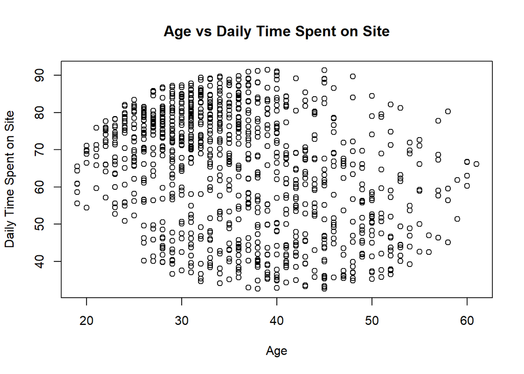

```r
#scatter plot
plot(age, time, xlab = 'Age', ylab = 'Daily Time Spent on Site', main = 'Age vs Daily Time Spent on Site')
```

From the scatter plot, we can see that as the age increases, time spent on site redices and vice versa.

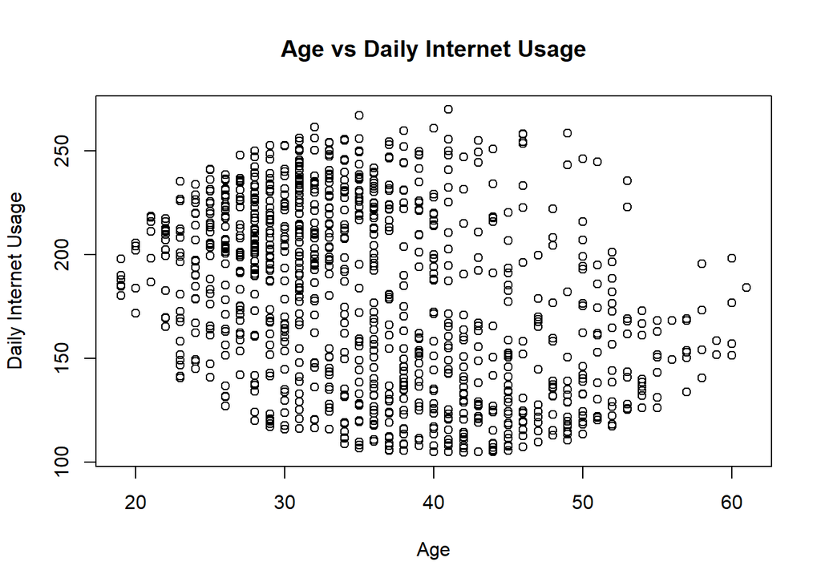

```r
#scatter plot
plot(age, units, xlab = 'Age', ylab = 'Daily Internet Usage', main = 'Age vs Daily Internet Usage')
```

From this scatter plot, we can see that as the age increases, the daily internet usage reduces and vice versa.

## Conclusion

From the univariate data analysis, we can conclude that:

- There were more females than males in our dataset.
- Individuals who are between 28 and 36 years old were the most in our dataset.
- Czech Republic and France both had the highest number of individuals (9) in the dataset.
- The dataset was balanced in the sense that 500 individuals clicked on the ads while 500 individuals did not click on the ads.
- Lisamouth and Williamsport cities both had the highest number of individuals (3) in the dataset.

From the bivariate data analysis, we can conclude that:

- There is a negative covariance and correlation between age and daily time spent on the site which means that the older an individual is, the less time they spend on the site.
- There is also a negative covariance and correlation between age and the daily internet usage which means that the younger an individual is, the higher the internet usage is as compared to an older individual.

## Recommendations

- She should create ads that targets individuals aged between 25 and 35 years old seeing as they are the most in our dataset.
- She should focuse on the youth more as they use the internet more and spend more time on the site as compared to the older individuals.